# Project 2: Data Mining, Classification, Prediction

SDS322E

# Mining, Classification, Prediction

## Debbie Gonzalez, dg37725

### Introduction

name: Name of song// album: Name of album// artist: Name of artist/s involved// release_date: Release date of album// length: Song length in milliseconds// popularity: Percent popularity of the song based on Spotify’s algorithm (possibly the number of stream at a certain period of time)// danceability: How suitable a track is for dancing based on a combination of musical elements including tempo, rhythm stability, beat strength, and overall regularity// acousticness: How acoustic a song is// energy: A perceptual measure of intensity and activity// instrumentalness: The amount of vocals in the song// liveness: Probability that the song was recorded with a live audience//

```r
library(tidyverse)
spotify_taylorswift <- read_csv("~/project2/spotify_taylorswift.csv")
spotify_taylorswift$Binary <- ifelse(spotify_taylorswift$popularity >
    60, "True", "False")
```

### Cluster Analysis

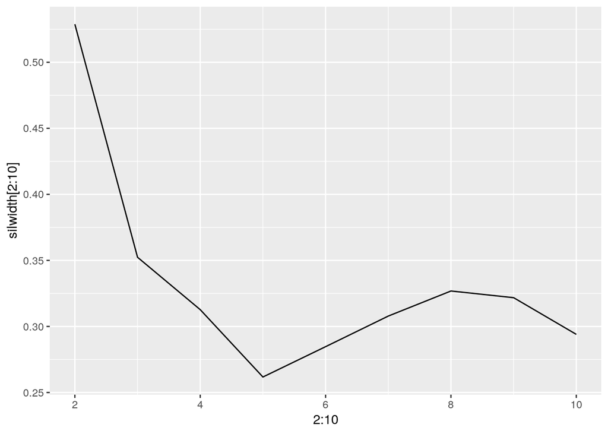

```r
library(cluster)
# clustering code here

clusterr <- spotify_taylorswift %>% select(popularity, danceability,
    acousticness)
silwidth <- vector()

gower1 <- daisy(clusterr, metric = "gower")

for (i in 2:10) {
    q1 <- clusterr %>% daisy("gower") %>% pam(k = i, diss = T)
    silwidth[i] <- q1$silinfo$avg.width
}
ggplot() + geom_path(aes(x = 2:10, y = silwidth[2:10]))
```

```r
cluster_pam <- clusterr %>% pam(k = 2)

cluster_pam
```

```
## Medoids:
##       ID popularity danceability acousticness
## [1,]  20         48        0.583        0.183
## [2,] 134         65        0.546        0.418
## Clustering vector:
##   [1] 1 1 2 1 1 1 1 1 1 1 1 1 1 1 1 1 1 1 1 1 1 1 1 1 1 1 1 1 1 1 1 1 2 1 2 1 2
##  [38] 2 2 2 2 2 2 2 2 2 2 2 2 2 2 2 2 2 2 1 1 1 1 2 2 2 2 2 2 2 2 2 2 2 2 2 2 2
##  [75] 2 1 1 1 2 2 2 2 2 2 2 2 2 2 2 2 2 2 2 2 2 2 2 2 2 2
##  [ reached getOption("max.print") -- omitted 71 entries ]
## Objective function:
##    build     swap
## 4.992947 4.786902
##
## Available components:
##  [1] "medoids"    "id.med"     "clustering" "objective"  "isolation"
##  [6] "clusinfo"   "silinfo"    "diss"       "call"       "data"
```

```r
cluster_pam$silinfo$avg.width
```

```
## [1] 0.6468007
```

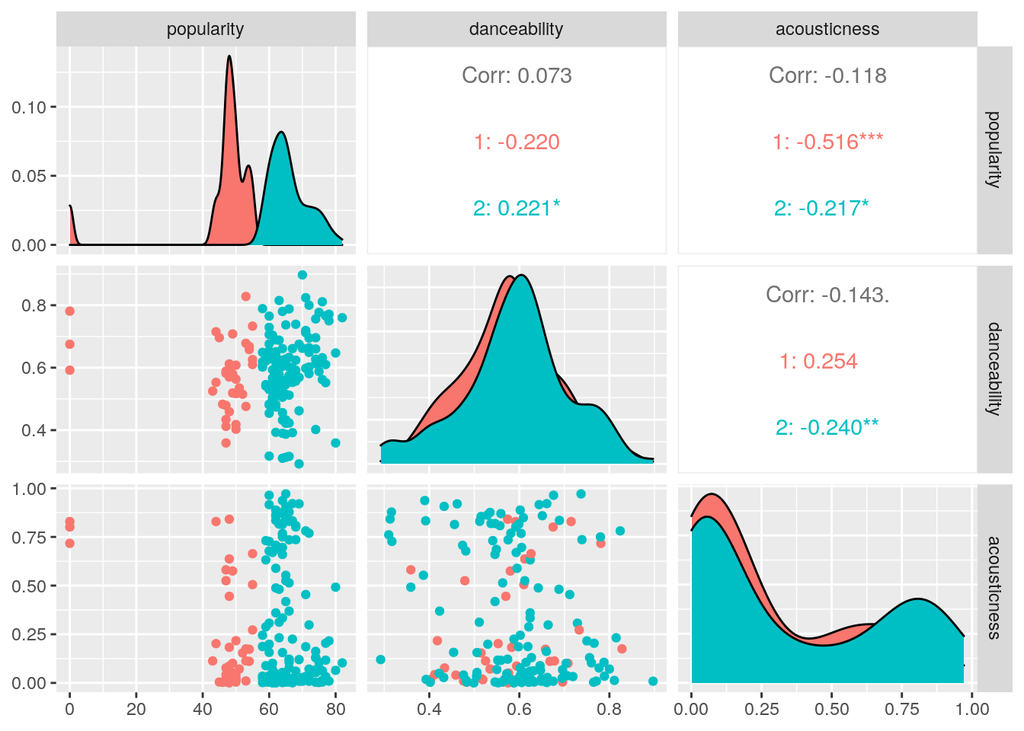

```r
library(GGally)
clusterr %>% mutate(cluster = as.factor(cluster_pam$clustering)) %>%
    ggpairs(columns = 1:3, aes(color = cluster))
```

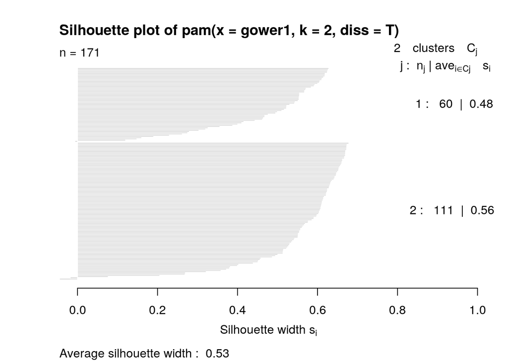

```r
pam <- pam(gower1, k = 2, diss = T)  #tell pam you are using dissimilarities
plot(pam, which = 2, color = "dark blue")
```

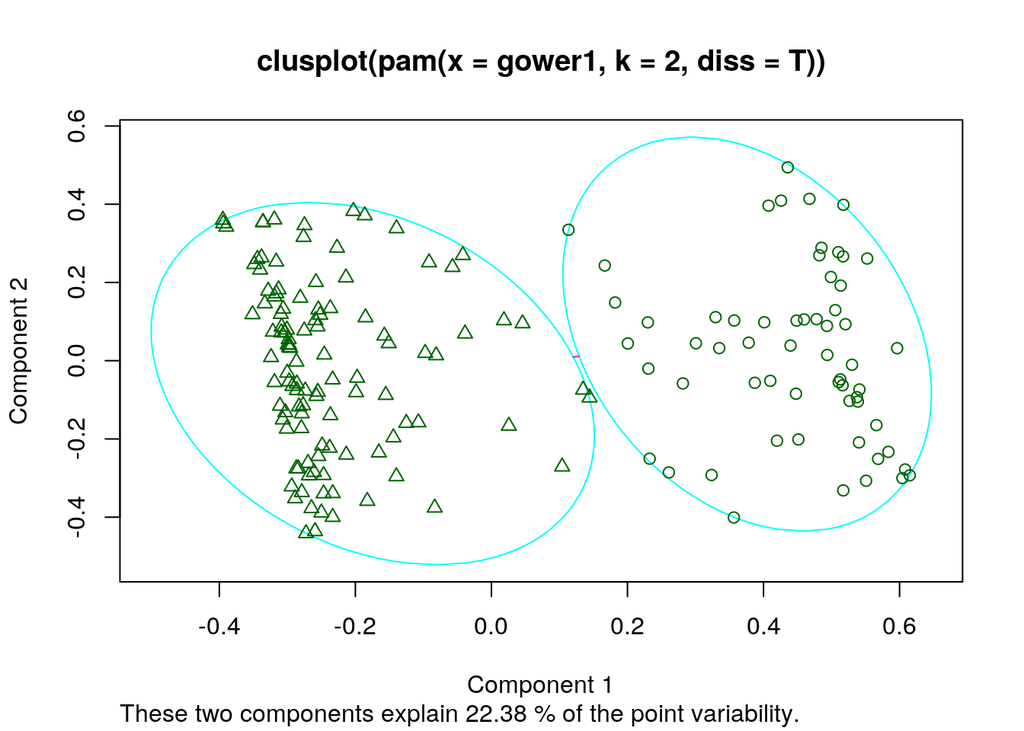

```r
plot(pam, which = 1)
```

Here I performed a cluster analysis by (1) choosing the number of clusters that maximizes average silhouette width (k=2), and (2) running the PAM clustering algorithm on the data for that many clusters. Based on the average silhouette width of 0.6468007, the cluster solution is reasonable.

I used my data, added the PAM cluster assignments as a factor or character variable, and then plotted every pairwise scatterplot using the `ggpairs(cols= 1:3, aes(color=cluster))` function. Popularity shows the biggest difference between the clusters, and danceability shows the least difference between the clusters.

### Dimensionality Reduction with PCA

```r
# PCA code here

pca1 <- princomp(clusterr, cor = T)

summary(pca1)
```

```
## Importance of components:
##                           Comp.1    Comp.2    Comp.3
## Standard deviation     1.1067006 0.9639962 0.9197419
## Proportion of Variance 0.4082621 0.3097629 0.2819750
## Cumulative Proportion  0.4082621 0.7180250 1.0000000
```

```r
eigval <- pca1$sdev^2
varprop = round(eigval/sum(eigval), 2)
round(cumsum(eigval)/sum(eigval), 2)
```

```
## Comp.1 Comp.2 Comp.3
##   0.41   0.72   1.00
```

```r
summary(pca1, loadings = T)
```

```
## Importance of components:
##                           Comp.1    Comp.2    Comp.3
## Standard deviation     1.1067006 0.9639962 0.9197419
## Proportion of Variance 0.4082621 0.3097629 0.2819750
## Cumulative Proportion  0.4082621 0.7180250 1.0000000
##
## Loadings:
##              Comp.1 Comp.2 Comp.3
## popularity    0.518  0.793  0.322
## danceability  0.572 -0.601  0.559
## acousticness -0.636  0.105  0.765
```

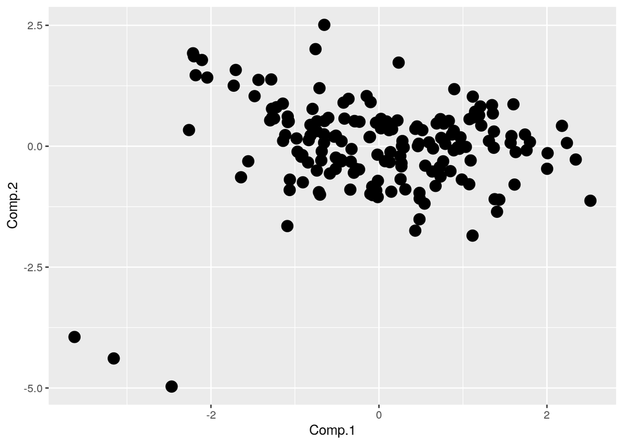

```r
df <- pca1$scores %>% as.data.frame()

df %>% ggplot(aes(x = Comp.1, y = Comp.2)) + geom_point(size = 4)
```

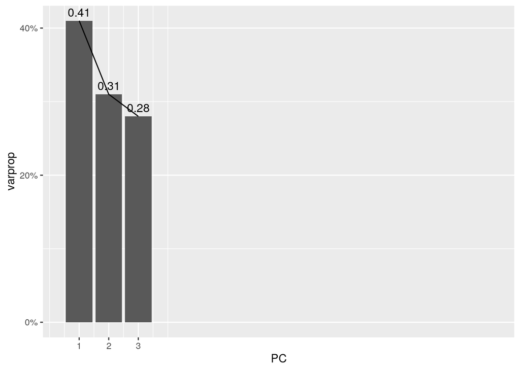

```r
varprop = round(eigval/sum(eigval), 2)  #proportion of var explained by each PC
ggplot() + geom_bar(aes(y = varprop, x = 1:3), stat = "identity") +
    xlab("PC") + geom_path(aes(y = varprop, x = 1:3)) + geom_text(aes(x = 1:3,
    y = varprop, label = round(varprop, 2)), vjust = -0.5, size = 4) +
    scale_y_continuous(breaks = seq(0, 0.6, 0.2), labels = scales::percent) +
    scale_x_continuous(breaks = 1:3, limits = c(0.5, 15))
```

The PCs represent the correlation between popularity and danceability and acousticness. Scoring high/low on each of these components means there is either a high/low correlation between popularity and danceability and acousticness. A large number of my total variance in my dataset is explained by these PCs. I notice that if a song has high popularity, it tends to have high PC1 scores

### Linear Classifier

```r
# linear classifier code here

library(knitr)
opts_chunk$set(fig.align = "center", fig.height = 5, message = FALSE,
    warning = FALSE, fig.width = 8, tidy.opts = list(width.cutoff = 60),
    tidy = TRUE)

class_diag <- function(score, truth, positive, cutoff = 0.5) {

    pred <- factor(score > cutoff, levels = c("TRUE", "FALSE"))
    truth <- factor(truth == positive, levels = c("TRUE", "FALSE"))

    tab <- table(truth, pred)
    acc = sum(diag(tab))/sum(tab)
    sens = tab[1, 1]/rowSums(tab)[1]
    spec = tab[2, 2]/rowSums(tab)[2]
    ppv = tab[1, 1]/colSums(tab)[1]

    # CALCULATE F1
    f1 = 2 * (sens * ppv)/(sens + ppv)

    # CALCULATE EXACT AUC
    truth <- as.numeric(truth == "TRUE")
    ord <- order(score, decreasing = TRUE)
    score <- score[ord]
    truth <- truth[ord]
    TPR = cumsum(truth)/max(1, sum(truth))
    FPR = cumsum(!truth)/max(1, sum(!truth))
    dup <- c(score[-1] >= score[-length(score)], FALSE)
    TPR <- c(0, TPR[!dup], 1)
    FPR <- c(0, FPR[!dup], 1)
    n <- length(TPR)
    auc <- sum(((TPR[-1] + TPR[-n])/2) * (FPR[-1] - FPR[-n]))
    round(data.frame(acc, sens, spec, ppv, f1, ba = (sens + spec)/2,
        auc, row.names = "Metrics"), 4)
}

logistic_fit <- glm(Binary == "True" ~ danceability + acousticness,
    data = spotify_taylorswift, family = "binomial")

prob_reg <- predict(logistic_fit)

class_diag(prob_reg, spotify_taylorswift$Binary, positive = "True")
```

```
##            acc   sens   spec ppv   f1     ba    auc
## Metrics 0.5673 0.5727 0.5574 0.7 0.63 0.5651 0.5681
```

```r
table(truth = factor(spotify_taylorswift$Binary == "True", levels = c("TRUE",
    "FALSE")), prediction = factor(prob_reg > 0.5, levels = c("TRUE",
    "FALSE")))
```

```
##        prediction
## truth   TRUE FALSE
##   TRUE    63    47
##   FALSE   27    34
```

```r
# cross-validation of linear classifier here

set.seed(322)
k = 10

data <- sample_frac(spotify_taylorswift)  #randomly order rows
folds <- rep(1:k, length.out = nrow(data))  #create folds

diags <- NULL

i = 1
for (i in 1:k) {
    # create training and test sets
    train <- data[folds != i, ]
    test <- data[folds == i, ]
    truth <- test$Binary

    # train model
    fit <- glm(Binary == "True" ~ danceability + acousticness,
        data = train, family = "binomial")

    # test model
    probs <- predict(fit, test)

    # get performance metrics for each fold
    diagsi <- class_diag(probs, truth, positive = "True")
    diags <- rbind(diags, diagsi)
}

# average performance metrics across all folds
summarize_all(diags, mean)
```

```
##      acc    sens    spec     ppv      f1      ba     auc
## 1 0.4794 0.52349 0.42631 0.62312 0.56106 0.47491 0.53031
```

The model is performing less than good per AUC. I do not see any signs of overfitting (I did not see a noticeable decrease in AUC when predicting out of sample).

### Non-Parametric Classifier

```r
library(caret)
# non-parametric classifier code here
attach(spotify_taylorswift)
knn_fit <- knn3(Binary == "True" ~ danceability + acousticness,
    data = spotify_taylorswift)
prob_reg <- predict(knn_fit)
diag_knn <- class_diag(prob_reg[, 2], spotify_taylorswift$Binary,
    positive = "True")
print(diag_knn)
```

```
##            acc   sens   spec    ppv     f1    ba    auc
## Metrics 0.6901 0.8545 0.3934 0.7176 0.7801 0.624 0.7385
```

```r
table(truth = factor(Binary == "True", levels = c("TRUE", "FALSE")),
    prediction = factor(prob_reg[, 1] > 0.5, levels = c("TRUE",
        "FALSE")))
```

```
##        prediction
## truth   TRUE FALSE
##   TRUE    16    94
##   FALSE   24    37
```

```r
# cross-validation of np classifier here
set.seed(322)
k = 10
data <- sample_frac(spotify_taylorswift)  #randomly order rows
folds <- rep(1:k, length.out = nrow(data))  #create folds

diags <- NULL

i = 1
for (i in 1:k) {
    # create training and test sets
    train <- data[folds != i, ]
    test <- data[folds == i, ]
    truth <- test$Binary

    # train model
    knn_fit <- knn3(Binary == "True" ~ danceability + acousticness,
        data = train)

    # test model
    prob_knn <- predict(knn_fit, test)

    # get performance metrics for each fold
    diags <- rbind(diags, class_diag(prob_knn[, 2], truth, positive = "True"))
}

# average performance metrics across all folds
summarize_all(diags, mean)
```

```
##       acc    sens   spec     ppv      f1      ba     auc
## 1 0.54412 0.76673 0.1512 0.62178 0.67881 0.45896 0.41814
```

The model is performing less than good per AUC. I do see signs of overfitting because I see a real decrease in AUC when predicting out of sample. I believe my previous model preformed better in its cross-validation performance.

### Regression/Numeric Prediction

```r
# regression model code here
fit <- lm(popularity ~ ., data = clusterr)  #predict popularity from all other variables
yhat <- predict(fit)  #predicted popularity
mean((clusterr$popularity - yhat)^2)  #mean squared error
```

```
## [1] 138.4858
```

```r
# cross-validation of regression model here
set.seed(1234)
k = 5  #choose number of folds
data <- clusterr[sample(nrow(clusterr)), ]  #randomly order rows
folds <- cut(seq(1:nrow(clusterr)), breaks = k, labels = F)  #create folds
diags <- NULL
for (i in 1:k) {
    train <- data[folds != i, ]
    test <- data[folds == i, ]
    ## Fit linear regression model to training set
    fit <- lm(popularity ~ ., data = train)
    ## Get predictions/y-hats on test set (fold i)
    yhat <- predict(fit, newdata = test)
    ## Compute prediction error (MSE) for fold i
    diags <- mean((test$popularity - yhat)^2)
}
mean(diags)  ## get average MSE across all folds (much higher error)!
```

```
## [1] 177.5335
```

### Python

```r
library(reticulate)
grammy <- "Taylor Swift is"
cat(c(grammy, py$grammy))
```

```
## Taylor Swift is
```

```python
# python code here
grammy = "the best!"
print(r.grammy, grammy)
```

```
## Taylor Swift is the best!
```

The reticulate package includes a Python engine for R Markdown that enables easy interoperability between Python and R; Python and Rhave full access to each other’s objects. All objects created within Python chunks are available to R using the py (py$) object exported by library(reticulate), similarly, R objects within Python chunks via the r (.r) object.

### Concluding Remarks

I’ve enjoyed working on this project and learned so much about data mining, classification, and prediction in R. I’ve also learned Python for data science and I’m excited to continue my knowledge!